# Final Project for STAR Project

# 3 Research Questions

## 3.1 Assumptions

- **Stable Unit Treatment Value Assumption (SUTVA):**

A first assumption is no interference. Each classroom’s potential outcome is assumed to be independent of the treatment assigned to other classrooms. The second assumption is no hidden versions of treatment. Small class should not contain multiple hidden versions of treatment.

- **Positivity:**

Within the relevant strata of background characteristics such as grade, race, free lunch status, and school context, there should be sufficient overlap so that no subgroup is deterministically assigned to only one class type.

- **Conditional ignorability of attrition:**

Conditional on the observed baseline covariates, treatment status, prior achievement, and other auxiliary variables related to student performance and participation, whether a student remains observed is assumed to be independent of the missing potential math outcomes.

- **Random assignment at baseline:**

At study entry, students were randomly assigned within schools to class types, so baseline treatment assignment can be treated as independent of students’ pre-treatment characteristics and potential outcomes.

- **Exclusive Restriction:**

Conditional on the class type actually received, the original random assignment affects math achievement only through treatment receipt, not through any direct channel such as parental responses, administrative reassignment, compliance behavior, etc.

## 3.2 Questions of Interests

1. **Does the small-class advantage persist?**
2. **Is the treatment effect stable across grades?**
3. **How do missingness and attrition affect the conclusions?**

# 4 Exploratory Data Analysis

## 4.1 Data Cleaning and Preprocessing

The dataset downloaded from Harvard Dataverse was first examined. It contains 11,601 observations and 379 variables, with a total of 2,477,601 missing entries. Given its large size and substantial amount of missing data, it is necessary to retain only variables relevant to the analysis and to address missingness carefully.

| variables | levels | N | freq | ratio | rank |
| --- | --- | --- | --- | --- | --- |
| student_gender | 1 | 25013 | 12957 | 51.80106345 | 1 |
| student_gender | 2 | 25013 | 12056 | 48.19893655 | 2 |
| student_race | 1 | 25013 | 16648 | 66.55739016 | 1 |
| student_race | 2 | 25013 | 8221 | 32.86690921 | 2 |
| student_race | 3 | 25013 | 63 | 0.25186903 | 3 |
| student_race | 6 | 25013 | 35 | 0.13992724 | 4 |
| student_race | 4 | 25013 | 33 | 0.13193140 | 5 |
| student_race | 5 | 25013 | 13 | 0.05197297 | 6 |
| grade | 1 | 25013 | 6583 | 26.31831448 | 1 |
| grade | 3 | 25013 | 6442 | 25.75460760 | 2 |

[output cut: 28 more lines]

Following the Project STAR codebook, we recoded several categorical variables and collapsed categories when the original coding was too sparse for stable analysis. In particular, student race and teacher race were simplified to Black vs. Non-Black, since the STAR documentation shows that racial categories other than White and Black were extremely rare in the data. Teacher degree was reduced to Below Master versus Master or above, because specialist and doctoral categories were infrequent relative to the dominant bachelor’s/master’s groups. Teacher career stage was also collapsed into Lower level and Upper level, since the original multi-level ladder structure was highly imbalanced in practice.

## 4.2 Identification of potential precision variables

Let the variables be defined as follows:

- $Y$: Outcome variable — students’ **math scores**.
- $X$: Treatment variables — **class type, grade level, and their interaction (class type × grade)**.
- $Z$: Potential precision variables — **school area type, free lunch status, student race, teacher race, and teacher degree, etc**.
- $A$: Ancillary variables — **treads (reading), tlists (listening), wordsk (word skills), motivr (motivation), selfco (self-concept), and lagged math scores from previous grades**.

Our objective is to estimate the effect of class size on students’ mathematics achievement in the STAR experiment. Although the initial assignment was randomized, factors such as classroom reassignment and student mobility may weaken the ideal experimental conditions. As a result, background characteristics may influence both classroom assignment and student outcomes.

A variable $Z$ acts as a precision variables if it is associated with both the treatment $X$ (class type) and the outcome $Y$ (math score). Thus we examine three relationships:

- **$X \rightarrow Y$:** whether class type is associated with math achievement.
- **$Z \rightarrow Y$:** whether background characteristics are associated with math achievement.
- **$Z \rightarrow X$ or $X \leftarrow Z \rightarrow Y$:** whether background characteristics are related to classroom assignment.

If these relationships hold, failing to control for $Z$ may bias estimates of the effect of class size on student outcomes. Therefore, these variables are included as controls in the subsequent analysis.

(**Why these are considered as precision variables not mediators?** A mediator must be caused by the treatment and lie on the pathway from class type to math achievement. In contrast, the background variables considered here—such as student gender, race, family disadvantage, and school context—are pre-treatment characteristics determined before class assignment and are not plausibly affected by class type.

*More generally, baseline covariates may still be appropriate adjustment variables as long as they are measured prior to treatment and are not themselves affected by treatment. In applied settings, such variables are often included to account for systematic pre-existing differences, thereby reducing bias and improving precision. By contrast, post-treatment variables, colliders, and selection indicators should generally not be conditioned on, since doing so may distort the estimated treatment effect*.)

### 4.2.1 Verify **$X \rightarrow Y$:**

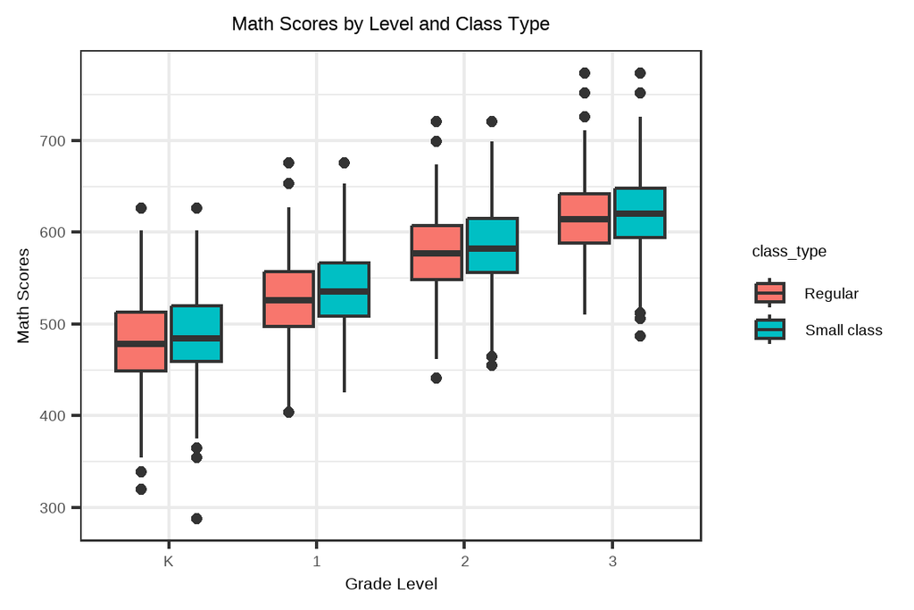

The boxplots show the distribution of students’ mathematics scores by grade level (K–3) and class type (small class/regular class). We can see that math scores increase steadily across grades. Also, students in small classes consistently exhibit slightly higher math scores than those in regular classes within the same grade. Thirdly, the difference between small classes and regular classes appears to persist across all grade levels, suggesting a potential interaction between grade and class type. In particular, the gap between the two class types appears to be slightly larger in lower grades. Thus, we can say that $X \rightarrow Y$ exists.

### 4.2.2 Examine potential variables that **$Z \rightarrow Y$:**

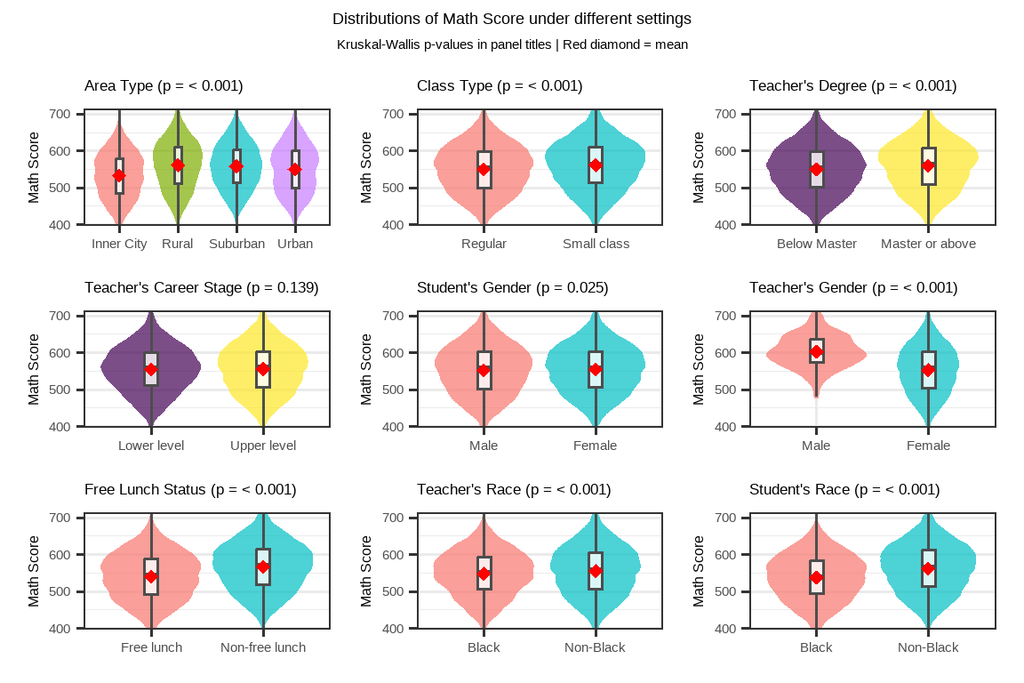

The figure compares math score distributions across several student, teacher, and school characteristics. As we can see, some of the distribution of data has a strong violations of normality. So we use Kruskal–Wallis test to evaluate whether math scores differ across groups. Unlike the ANOVA, Kruskal–Wallis it is a nonparametric method based on ranks, which means that there are no normality assumption of data.

The null hypothesis of Kruskal–Wallis is that the distributions of math scores are the same across all groups; equivalently, under a common-shape assumption, the group medians are equal. The alternative hypothesis is that at least one group differs from the others.

Because multiple tests are conducted across several covariates, we adopt a significance threshold of $\alpha =0.001$ to reduce the risk of false positives arising from multiple comparisons and the large sample size of the STAR dataset. The figure compares math score distributions across several student, teacher, and school characteristics.

In this case, Kruksal–Wallis p–value of **area type, free lunch status, student race, teacher race, teacher gender, and teacher degree** are less or equal than 0.001. Thus, we reject the null hypothesis, showing that they are significant factors that influence students’ mathematics performance, indicating their relationship of $Z \rightarrow Y$. To determine whether they act as precision variables, we further examine whether these variables are also associated with class type (or to say $Z \rightarrow X$ exists).

### 4.2.3 Examine precision variables that satistfies **$Z \leftarrow X \rightarrow Y$:**

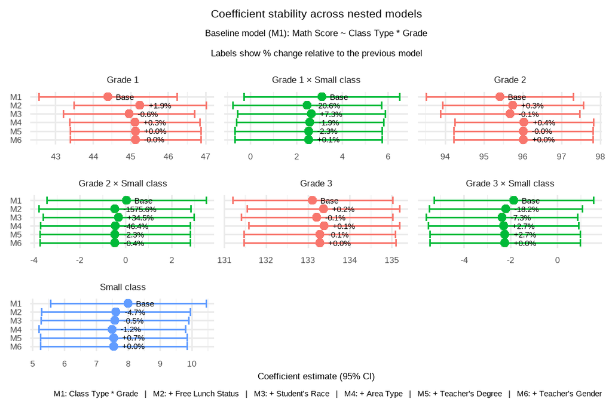

Equivalent to the linear regression model

$$Y_i=\alpha+X_i^\top\beta+Z_i^\top\gamma+\varepsilon_i,$$

where $Y_i$ is math score, $X_i$ contains the treatment-related design terms for class type, grade, and their interaction terms, and $Z_i$ contains candidate precision variables added sequentially across nested models. The figure tracks how the estimated coefficients $\beta$ change as additional covariates $Z_i$ are added step by step into the regression model. Each panel corresponds to one coefficient, each point is the estimate from a given model, and each horizontal line is its 95% confidence interval. The percentages show how much the coefficient changes relative to the previous model.

The goal is to assess whether adding a covariate substantially changes the estimated effects of treatment variables. If a coefficient shifts noticeably after a variable is added, that variable may be acting as a precision variables. As a heuristic, a covariate is flagged as a potential precision variables if its inclusion changes a focal class-type coefficient by more than 10% in absolute value.

In this plot, the largest changes occur after adding free lunch status, area type and student’s race, while later adding teacher’s degree and gender does not changes the coefficient of treatment effects. This suggests that these three variables account for the main confounding in the relationship of $Z \rightarrow X$ or adding $Z$ changes how $X \rightarrow Y$. Thus, in our final model we need to conditioning on the effects of free lunch status, area type and student’s race in order to accurately estimate the effect of treatment variable.

## 4.3 Analysis of missing mechanism

- **MCAR (Missing Completely at Random)**: the probability of missingness is unrelated to both observed and unobserved data. In this case, missing values occur purely by chance, dropping incomplete cases does not introduce bias.
- **MAR (Missing at Random)**: the probability of missingness may depend on observed variables, but conditional on those observed variables, it does not depend on the missing value itself.
- **MNAR (Missing Not at Random)**: the probability of missingness still depends on the unobserved value itself, even after conditioning on observed data. This cannot be verified directly from the observed data alone, because the mechanism depends on values that are not observed.

In practice, these mechanisms cannot usually be distinguished with certainty from the observed data alone, especially in distinguishing MAR and MNAR. Therefore, rather than attempting to verify MAR directly, we assess its plausibility indirectly using the following diagnostic strategies:

- **Assess whether missingness is explainable by observed data**: model the missingness indicator using baseline covariates, lagged outcomes, and other observed variables. If missingness can be substantially explained by observed information, the MAR assumption becomes more plausible. (Rubin 1976)
- **Include strong auxiliary variables**: add variables that are highly predictive of the missing outcome or of the missingness process into the imputation or likelihood-based model. This can reduce bias and strengthen the plausibility of MAR. (Collins, Schafer, and Kam 2001); (White, Royston, and Wood 2011)
- **Check robustness under MAR-based methods**: compare results across approaches such as complete-case analysis, IPW, FIML, and MI under the same observed-data structure. Similar conclusions make MAR-based inference more credible. (Baraldi and Enders 2010)
- **Conduct MNAR sensitivity analysis**: evaluate how conclusions change under plausible departures from MAR using methods such as pattern-mixture models, selection models, or delta-adjusted imputation. Stable results suggest that the main findings are not overly sensitive to violations of MAR. (Daniels 2000)

### 4.3.1 Proving data is not MCAR

Each student’s outcome record is summarized by a four-digit indicator over grades K, 1, 2, 3, where 1 denotes an observed math score and 0 denotes a missing math score. For example, 1111 indicates complete observation across all four grades and 1001 indicates a non-monotone pattern with observation in K and Grade 3 but missingness in between.

We classified the K–3 observation patterns into five descriptive groups:

- Pattern 1111 was defined as **complete cases**.
- Patterns 1110, 1100, 1000, 0100, and 0110 were grouped as **monotone attrition**, since once students entered a missing state, they did not subsequently return to full follow-up.
- Patterns 0011 and 0001 were classified as **late entry**, as observations only began in later grades.
- Patterns 1010, 1001, 0101, 0010, and 1011 were classified as **intermittent**, reflecting non-monotone missingness with reappearance after one or more missing waves.
- Pattern 0111 was separated as **no records in K**, because it there are a specific group of students who hasn’t got kindergarten but observed continuously from Grade 1 onward.

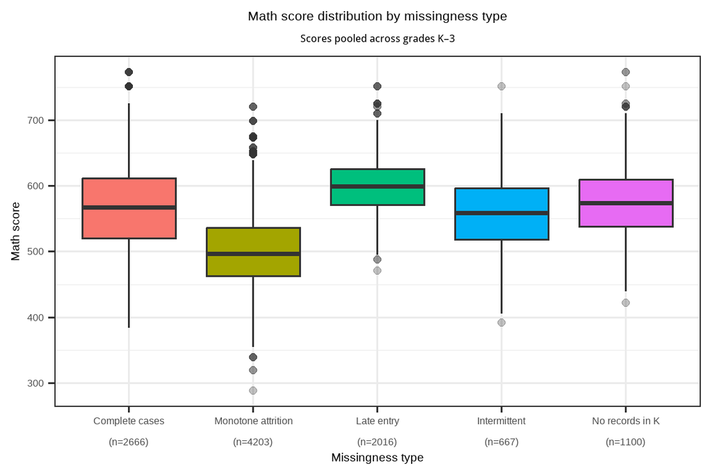

The boxplot shows clear differences in pooled math-score distributions across missingness types from kindergarten to Grade 3. The pooled math-score distributions suggest that complete cases, intermittent cases, have broadly similar achievement levels. However, **the monotone attrition group has lower math score while the late-entry group shows significant higher math score among all categories**. The pattern suggests that missingness type is related to student performance, which is inconsistent with a purely MCAR mechanism. Thus, missingness type itself is informative and should be analyzed specifically.

### 4.3.2 Examine whether missingness can be explained by observed variables

Baseline characteristics by completeness status

| Variable | Complete | Incomplete | p | SMD |
| --- | --- | --- | --- | --- |
| n | 2666 | 8104 |  |  |
| Math score, mean (SD) | 498.85 (44.58) | 474.17 (47.31) | <0.001 | 0.537 |
| Free lunch: Non-free lunch, n (%) | 1682 (63.2) | 1491 (43.1) | <0.001 | 0.412 |
| Student race: Non-Black, n (%) | 2009 (75.4) | 4813 (59.6) | <0.001 | 0.341 |
| Student gender: Female, n (%) | 1367 (51.3) | 3714 (45.8) | <0.001 | 0.109 |
| Class type: Small class, n (%) | 831 (31.2) | 1020 (29.3) | 0.122 | 0.041 |
| Area type, n (%) |  |  | <0.001 | 0.429 |
| Inner City | 402 (15.1) | 973 (28.0) |  |  |
| Rural | 1544 (57.9) | 1323 (38.0) |  |  |
| Suburban | 515 (19.3) | 840 (24.1) |  |  |
| Urban | 205 (7.7) | 344 (9.9) |  |  |
| Class size, mean (SD) | 19.97 (3.88) | 20.58 (4.02) | <0.001 | 0.154 |

### 4.3.3 Include strong auxiliary variables

| variable | n | correlation |
| --- | --- | --- |
| treads | 24179 | 0.8757215 |
| wordsk | 23883 | 0.8540292 |
| tlists | 24398 | 0.8376455 |
| math_lag1 | 13504 | 0.8074844 |
| mathbs | 18295 | 0.7563878 |
| math_lag2 | 7236 | 0.6543246 |
| readbs | 18227 | 0.5989453 |
| motivr | 21785 | 0.5258207 |
| math_lag3 | 2887 | 0.4780006 |

We examined the auxiliary variables including reading score (treads), word skills (wordsk), listening score (tlists), and lagged math scores. They have shown strong correlations with math achievement, which is informative for predicting missing math outcomes and can be included in the imputation model to reduce bias. This could be considered a case of satisfying the MAR assumption.

# 5 Methodology

For several variables that are regarded as time-invariant or relatively stable over time such as gender and race/ethnicity, we applied the Last Observation Carried Forward (LOCF) approach. This works by replacing the most recent previously observed value for the same student when the value was missing at a later wave.

## 5.1 Introduction of Key Methods

Because our dataset contains a substantial proportion of incomplete cases across various waves, relying solely on complete-case analysis (IPW) would lead to severe information loss and biased estimates. Therefore, **we employ a rigorous two-step hybrid approach combining Multiple Imputation by Chained Equations (MICE) and Augmented Inverse Probability Weighting (AIPW).** First, we utilize MICE to address the **sheer volume of incomplete cases** by MICE. Second, because individual **student trajectories can be highly sparse over time**, we apply AIPW in the subsequent analysis phase. AIPW could be a correction for any residual bias caused by the sparsity of individual math trajectories and potential misspecifications during the MICE step.

### 5.1.1 MICE (Multiple Imputation by Chained Equations)

**1. The Chained Equations (Conditional Imputation Models)**

Let $V = (Y, X, Z, A)$ represent the full set of variables in our dataset, where $V_j$ denotes the $j$-th variable and $V_{-j}$ denotes all variables except $V_j$. The MICE algorithm operates by drawing missing values from a sequence of conditional distributions. For an iteration $t$, the missing values of variable $V_j$, denoted as $V_{j, mis}$, are drawn from the conditional distribution given the observed values $V_{j, obs}$ and the currently imputed values of all other variables:

$$V_{j, mis}^{(t)} \sim P(V_j \mid V_1^{(t)}, \dots, V_{j-1}^{(t)},
V_{j+1}^{(t-1)}, \dots, V_p^{(t-1)}, \theta_j^{(t)})$$

where $\theta_j^{(t)}$ is a vector of parameters specific to the conditional model for variable $V_j$ at iteration $t$.

**2. Specific Models for Key Variables**

Because our dataset contains a mix of continuous and categorical variables with varying distributions, we assign specific conditional models to different variable types:

- **Continuous Variables** For students’ class size and teaching years, we utilize **Predictive Mean Matching (PMM)**. PMM is a semi-parametric approach that relaxes the assumption of normality. For a student $i$ with a missing math score $Y_i$, PMM first estimates a predictive linear model:

$$\hat{A}_{-i} = \beta_0 + \beta_X X_i + \beta_Z Z_i + \beta_A A_i$$

- **Categorical Variables ($X$ and $Z$):** For categorical baseline characteristics with missing values (e.g., $Z$: `free_lunch`, `student_race`, `area_type`), we employ generalized linear models. For instance, if $Z_k$ is a binary precision variable (e.g., `free_lunch`), we use logistic regression:

$$\text{logit}(P(Z_{k, i} = 1 \mid V_{-Z_k, i})) = \alpha_0 + \alpha^T
V_{-Z_k, i}$$

For categorical variables with more than two levels, multinomial logistic regression is applied.

**3. Imputation Parameters**

To adequately capture the uncertainty surrounding the missing data and the highly sparse regions of student performance, we set the number of multiple imputations to $m = 20$, generating 20 distinct, complete datasets. For each dataset, the chained equations run for $maxit = 10$ iterations to allow the conditional distributions to reach convergence, which will be verified visually via trace plots.

**4. Assumptions**

The validity of Multiple Imputation by Chained Equations (MICE) relies on several key statistical assumptions. Based on our previous diagnostic analyses, we align our imputation strategy with the following assumptions:

- **Missing at Random (MAR):** We previously rejected the strict MCAR assumption, showing that missingness is tied to baseline traits. By including these precision variables and strong auxiliary predictors in the imputation model, we largely explain the missingness mechanism, making the MAR assumption highly plausible.
- **Correct Model Specification:** To satisfy this, our predictor matrix incorporates the treatment variables ($X$), the outcome ($Y$), their interaction (class type $\times$ grade), and all identified precision ($Z$) and auxiliary ($A$) variables.
- **Ignorability:** Our rich set of covariates sufficiently accounts for systematic differences between complete and incomplete cases, we can rely on the conditional distributions estimated by MICE without explicitly modeling the dropout probability.
- **Compatibility of Conditional Distributions:** The sequence of conditional univariate models must be mutually compatible to converge to a valid stationary multivariate distribution. By utilizing standard generalized linear models, our MICE setup behaves robustly and satisfies the practical requirements of compatibility and convergence.

### 5.1.2 AIPW (Augmented Inverse Probability Weighting)

While MICE focuses on recovering missing values in the dataset based on observed patterns, AIPW operates at the causal estimation phase. It does not impute missing values to create a new dataset; rather, it “imputes” the unobserved potential outcomes mathematically to estimate the Average Treatment Effect (ATE). It achieves this by modeling both the probability of treatment assignment and the expected outcome.

**1. The Estimation and Correction Process**

Let the treatment assignment $X \in \{0, 1\}$ denote the class type a student was assigned to, where $X=1$ represents assignment to a Small Class (the treatment) and $X=0$ represents assignment to a Regular Class (the control). The AIPW estimation on the imputed datasets proceeds in three steps:

Firstly, we model the probability of a student receiving the treatment given their covariates, known as the propensity score: $\pi(Z_i) = P(X_i = 1 \mid Z_i)$. We use logistic regression to estimate $\hat{\pi}(Z_i)$. Inverse Probability Weighting (IPW) uses these scores to create a pseudo-population where treatment assignment is independent of measured confounders.

Next, we model the expected math score given the treatment and covariates: $\mu_x(Z_i) = E[Y_i \mid X_i = x, Z_i]$. We fit regression models (or machine learning algorithms) to obtain the predicted expected outcomes $\hat{\mu}_1(Z_i)$ (if treated) and $\hat{\mu}_0(Z_i)$ (if control) for every student.

AIPW estimates the counterfactual mean for treatment $x$ by augmenting the IPW estimator with predictions from the outcome model. The estimator for the expected potential outcome under treatment $X=1$ is constructed as:

$$\hat{E}[Y^{(1)}] = \frac{1}{N} \sum_{i=1}^N \left[ \hat{\mu}_1(Z_i) +
\frac{X_i}{\hat{\pi}(Z_i)} (Y_i - \hat{\mu}_1(Z_i)) \right]$$

This formula elegantly corrects predictions: if the outcome model $\hat{\mu}_1(Z_i)$ makes an error (the residual $Y_i - \hat{\mu}_1(Z_i)$), it is scaled by the inverse probability weight to adjust for the bias. The Average Treatment Effect (ATE) is simply the difference between the AIPW estimates for treatment and control: $\hat{ATE} = \hat{E}[Y^{(1)}] - \hat{E}[Y^{(0)}]$.

**2. Defending Our Causal Assumptions**

By employing this doubly robust estimator, we directly operationalize and safeguard the core causal assumptions established earlier in our methodology:

- **Safeguarding Positivity in Sparse Data:** As outlined in our assumptions, sufficient overlap (**Positivity**) is required across all strata.
- **Fortifying Conditional Ignorability:** Residual misspecification may still exist due to non-normality. AIPW offers a crucial “double-check” mechanism: it yields consistent and unbiased treatment effect estimates as long as *at least one* of the two models—either the outcome model or the propensity model—is correctly specified.

## 5.2 Imputations

### 5.2.1 Convergence check of MICE

To assess the convergence and stability of the multiple imputation procedure. For each category of each time-varying categorical variable, we calculated the average proportion across the 20 imputed datasets, as well as the range (minimum–maximum) of the proportions across imputations. This helps evaluate whether the imputation model produces consistent distributions across completed datasets. Narrow ranges and similar average proportions indicate good stability of the MICE.

Convergence Checking for Time-Varying Categorical Variables Across 20 Imputed Sets

| variable_label | category | Grade 1 | Grade 2 | Grade 3 | K |
| --- | --- | --- | --- | --- | --- |
| Class Type | Regular | 0.732 (0.730, 0.734) | 0.709 (0.706, 0.713) | 0.684 (0.678, 0.689) | 0.743 (0.739, 0.749) |
|  | Small class | 0.268 (0.266, 0.270) | 0.291 (0.287, 0.294) | 0.316 (0.311, 0.322) | 0.257 (0.251, 0.261) |
| Free Lunch Status | Free lunch | 0.552 (0.547, 0.555) | 0.552 (0.546, 0.558) | 0.549 (0.545, 0.553) | 0.538 (0.529, 0.546) |
|  | Non-free lunch | 0.448 (0.445, 0.453) | 0.448 (0.442, 0.454) | 0.451 (0.447, 0.455) | 0.462 (0.454, 0.471) |
| Teacher Career Level | Lower level | 0.301 (0.295, 0.306) | 0.247 (0.241, 0.253) | 0.203 (0.196, 0.210) | 0.172 (0.163, 0.180) |
|  | Upper level | 0.699 (0.694, 0.705) | 0.753 (0.747, 0.759) | 0.797 (0.790, 0.804) | 0.828 (0.820, 0.837) |
| Teacher Degree | Below Master | 0.659 (0.650, 0.664) | 0.624 (0.616, 0.630) | 0.557 (0.551, 0.563) | 0.661 (0.651, 0.669) |
|  | Master or above | 0.341 (0.336, 0.350) | 0.376 (0.370, 0.384) | 0.443 (0.437, 0.449) | 0.339 (0.331, 0.349) |
| Teacher Race | Black | 0.197 (0.193, 0.203) | 0.220 (0.212, 0.244) | 0.237 (0.231, 0.243) | 0.173 (0.164, 0.179) |
|  | Non-Black | 0.803 (0.797, 0.807) | 0.780 (0.756, 0.788) | 0.763 (0.757, 0.769) | 0.827 (0.821, 0.836) |

### 5.2.2 Stability of AIPW

To assess the stability of the inverse probability weighting procedure, we examined the distribution of the estimated propensity scores and the corresponding IPW weights across the imputed datasets. For each completed dataset, propensity scores for remaining in the study through Grade 3 were estimated using baseline covariates, including student race, gender, birth year, free lunch status at kindergarten, and school area type. IPW weights were then constructed as the inverse of the estimated propensity score for students who remained in the study.

**1. Distribution of Propensity Scores and AIPW Weights**

We examined the distributions of the estimated propensity scores and AIPW weights to assess whether the weighting procedure was stable. Adequate overlap and the absence of extreme weights suggest that the resulting AIPW estimates are reliable and not unduly influenced by a small number of observations.

Distribution of Propensity Scores and AIPW Weights

| Statistic | Propensity.Score | AIPW.Weight |
| --- | --- | --- |
| Mean | 0.540 | 1.909 |
| Standard deviation | 0.091 | 0.338 |
| Minimum | 0.281 | 1.257 |
| 1st percentile | 0.357 | 1.420 |
| 5th percentile | 0.397 | 1.452 |
| Median | 0.527 | 1.897 |
| 75th percentile | 0.613 | 2.146 |
| 95th percentile | 0.689 | 2.521 |
| 99th percentile | 0.704 | 2.802 |
| Maximum | 0.796 | 3.554 |

**2. Covariate Balance Before and After Weighting**

Standardized mean differences (SMDs) were examined before and after weighting to assess whether IPW improved covariate balance between treatment groups. Because IPW aims to reduce confounding by creating a weighted pseudo-population with similar observed covariate distributions across groups, balance diagnostics provide an important check on whether the weighting procedure performed as intended.

Standardized Mean Differences Before and After Weighting

| Covariate | Unweighted SMD Mean | Unweighted SMD Range | Weighted SMD Mean | Weighted SMD Range |
| --- | --- | --- | --- | --- |
| Birth year | 0.101 | 0.098-0.104 | 0.005 | 0.004-0.007 |
| Student race | 0.071 | 0.069-0.072 | 0.001 | 0.001-0.001 |
| Area type:Inner City | 0.067 | 0.059-0.077 | 0.001 | 0.000-0.001 |
| Free lunch | 0.128 | 0.121-0.136 | 0.000 | 0.000-0.001 |
| Area type:Rural | 0.115 | 0.106-0.122 | 0.000 | 0.000-0.001 |
| Student gender | 0.031 | 0.031-0.032 | 0.000 | 0.000-0.001 |
| Area type:Suburban | 0.029 | 0.023-0.039 | 0.000 | 0.000-0.000 |
| Area type:Urban | 0.019 | 0.012-0.025 | 0.000 | 0.000-0.000 |

# 6 Inferential Analysis

With adequate balance achieved, the weighted sample was then used for inferential analysis to obtain less confounded estimates of the relationship between treatment assignment and math outcomes over time. Covariate balance alone, however, does not by itself answer the substantive research question, as formal estimation is still needed to quantify the magnitude and uncertainty of the treatment effect. This section focuses on the final inferential model rather than the computational details used to prepare the data. The descriptive analysis suggests that complete-case inference would be difficult to justify: missingness is structured across grades, baseline characteristics differ by completeness status, and several auxiliary variables are predictive of achievement. These diagnostics do not prove MAR, and the EDA itself may contain imperfections, but they do make a purely MCAR explanation implausible. Accordingly, we proceed under a working assumption that a substantial part of the missing-data process can be explained by observed student- and school-level information (Rubin 1976; White, Royston, and Wood 2011; Finn et al. 2007).

## 6.1 Target estimand and treatment definition

Our primary estimand is the effect of initial kindergarten small-class assignment on K–3 mathematics outcomes. We deliberately use the kindergarten assignment indicator, rather than observed class type in every later grade, because the original randomization is cleanest at entry. By contrast, later observed class type is affected by mobility, reassignment, late entry, and the regular-versus-regular-aide restructuring documented in the STAR records and later analyses (Word et al. 1990; Finn et al. 2007; Ding and Lehrer 2006). Under this design-based perspective, kindergarten assignment retains a defensible connection to the original experiment, while a model based on later observed class type would mix experimental assignment with post-randomization behavior.

This choice also clarifies the interpretation of the final model. We are not estimating the contemporaneous effect of class size in each later grade. Instead, we estimate how the initial kindergarten assignment is associated with the subsequent trajectory of math achievement, after adjustment for observed covariates and selective follow-up.

## 6.2 Covariate completion before causal estimation

Before constructing the doubly robust estimator, we use multivariate imputation by chained equations (MICE) to complete incompletely observed covariates and auxiliary predictors that enter the retention and outcome models. This step is necessary because the doubly robust estimator requires a reasonably complete observed history for each student; otherwise, the propensity-to-remain model and the grade-specific outcome regressions would themselves be fitted on unstable or inconsistently restricted subsets of the data (Buuren and Groothuis-Oudshoorn 2011; White, Royston, and Wood 2011).

The role of MICE in this report is therefore not to replace the causal analysis, but to support it. We use fully conditional specification because the STAR data combine continuous and categorical variables, have irregular missingness across grades, and include predictors measured at multiple levels of the educational hierarchy. The imputation model includes treatment-related variables, baseline demographics, school identifiers, and auxiliary measures identified in the EDA as informative for later achievement. This is intended to make the conditional MAR assumption more plausible for the incomplete covariates used in the DR stage (White, Royston, and Wood 2011; Enders 2010).

An important design choice is that MICE is used to recover covariate information needed for the attrition and outcome models, while the final inferential stage continues to treat outcome missingness as a substantive problem. In other words, the completed datasets are used to stabilize the observed covariate history, but the original missingness structure of the math outcomes is restored before the DR pseudo-outcome is constructed. This keeps selective follow-up explicit in the causal analysis rather than hiding it inside a fully imputed outcome panel.

The MICE step is used under the following working assumptions:

- **Conditional MAR for incomplete covariates**: after conditioning on the observed treatment indicators, baseline demographics, school information, and auxiliary predictors included in the imputation model, the missingness of incomplete covariates does not depend on their unobserved values.
- **Sufficiently rich conditional models**: the fully conditional specification is flexible enough to preserve the main relationships among treatment, covariates, and auxiliary variables that are needed later in the DR stage.
- **Respect for hierarchical structure**: because students are nested within schools, school-level information must be represented during imputation so that the completed covariate history is compatible with the multilevel outcome analysis.

Under these assumptions, the completed datasets can be used to stabilize the observed covariate history before causal estimation, while still leaving outcome attrition to be handled explicitly in the next stage.

## 6.3 Final longitudinal mixed model

### 6.3.1 Limitations of complete-case analysis

The descriptive analysis suggests that complete-case inference would be difficult to justify. Missingness is structured across grades, baseline characteristics differ by completeness status, and several auxiliary variables are predictive of later achievement. These diagnostics do not prove MAR, and the EDA itself may contain imperfections, but they do make a purely MCAR explanation implausible. We therefore proceed under a working assumption that a substantial part of the missing-data process can be explained by observed student- and school-level information (Rubin 1976; White, Royston, and Wood 2011; Finn et al. 2007). Under that assumption, an analysis that ignores selective follow-up is less credible than one that adjusts for it directly.

### 6.3.2 Doubly robust adjustment for selective follow-up

The pseudo-outcome $\widetilde{Y}_{ig}$ is introduced to reduce bias from selective follow-up. The EDA suggests that attrition and intermittent observation are related to observed disadvantage and prior achievement, so an ordinary regression on complete cases would be vulnerable to selection bias. Following the augmented inverse-probability-weighting framework of Robins, Rotnitzky, and Zhao (1994), we combine a model for retention with a model for the observed math outcome. The key appeal is the double-robust property: the treatment-effect estimator remains consistent if either the retention model or the outcome model is correctly specified, even if the other is not (Funk et al. 2011; Seaman and Vansteelandt 2018). In the STAR setting, where Grade 3 attrition can be substantial and is unlikely to be captured perfectly by a single parametric model, this is a more defensible strategy than relying only on OLS adjustment (Krueger 1999b; Ding and Lehrer 2006).

The DR step is used under the following working assumptions:

- **Conditional ignorability of outcome missingness**: after conditioning on the observed treatment history, baseline covariates, and auxiliary information carried into the completed datasets, whether a student remains observed is independent of the unobserved potential math outcomes.
- **Positivity / overlap**: every relevant subgroup has a non-negligible probability of remaining in the observed sample, so the inverse-probability weights are well defined and not dominated by extreme values.
- **Limited interference (SUTVA)**: one student’s outcome can be interpreted with respect to their own initial assignment without being materially altered by the treatment status of other students.
- **Single-model protection through double robustness**: consistency of the DR estimator requires correct specification of at least one of the two nuisance models, namely the retention model or the outcome model (Robins, Rotnitzky, and Zhao 1994; Funk et al. 2011).

These assumptions are standard in causal analyses with missing outcomes, but they remain substantive rather than automatic (Seaman and Vansteelandt 2018; Dashti et al. 2024). Under them, the DR pseudo-outcome reduces dependence on any one parametric model and provides a more credible basis for the final longitudinal analysis.

### 6.3.3 Final model specification

Once the doubly robust pseudo-outcome is constructed, we summarize it with a longitudinal mixed-effects model. Let $\widetilde{Y}_{ig}$ denote the doubly robust pseudo-outcome for student $i$ at grade $g$, let $T_i$ denote the kindergarten small-class assignment indicator, let $X_i$ denote the baseline adjustment vector, let $s(i)$ index the student’s baseline school, and let $b_i$ denote a student-specific random intercept. The final model is
$$\widetilde{Y}_{ig} = \beta_0 + \beta_T T_i + \delta_g + \eta_g(T_i
\times \text{Grade}_g) + \gamma^\top X_i + u_{s(i)} + b_i +
\epsilon_{ig},$$
where $\delta_g$ captures average grade-to-grade growth, $\eta_g$ allows the effect of kindergarten assignment to vary by grade, $u_{s(i)} \sim N(0, \sigma^2_{\text{school}})$ is a school-level random intercept, $b_i \sim N(0, \sigma^2_{\text{student}})$ is a student-level random intercept, and $\epsilon_{ig}$ is an idiosyncratic error term. This follows the repeated-measures logic of Laird and Ware (1982) while adapting it to the clustered STAR design. With kindergarten as the reference grade, $\beta_T$ is interpreted as the small-class effect in kindergarten, and the grade-interaction terms describe how that initial effect changes in Grades 1, 2, and 3.

The final mixed model is interpreted under the following working assumptions:

- **Correct mean-structure specification**: the main systematic variation in the DR-adjusted outcome is adequately represented by initial treatment, grade, their interaction, and the selected adjustment covariates.
- **Appropriate dependence structure**: school-level and student-level random intercepts capture the dominant clustering induced by within-school assignment and repeated measurements on the same child.
- **Mean-zero residual variation**: conditional on the included fixed and random effects, the remaining residual component has mean zero and does not introduce systematic bias into the treatment coefficients.
- **Intent-to-treat style interpretation**: the fitted model is interpreted as a longitudinal analysis of initial assignment, not as a model of later contemporaneous class type after post-randomization switching.

Under these assumptions, the treatment main effect and treatment-by-grade interactions can be interpreted as summaries of how the initial kindergarten assignment relates to the subsequent K–3 achievement path. Two modeling choices deserve additional justification because they are central to the longitudinal interpretation: the multilevel random-effects structure and the treatment-by-grade interaction.

### 6.3.4 Multilevel dependence and random intercepts

Project STAR randomized class type within schools rather than across the entire state, so students within the same school are expected to share common institutional environments and administrative features. The school random intercept $u_{s(i)}$ captures this shared school-level variation and respects the blocked nature of the original design (Word et al. 1990; Finn et al. 2007). At the same time, each child contributes repeated outcomes across grades, so observations from the same student are inherently correlated. The student random intercept $b_i$ accounts for persistent person-level heterogeneity in achievement and aligns the model with the repeated-measures framework of Laird and Ware (1982). In diagnostic checks across all 20 imputed datasets, this additional random effect did not produce singular fits or convergence failures, and its variance component remained stable, so retaining both levels of clustering is empirically defensible.

### 6.3.5 Dynamic treatment effects across grades

The interaction between kindergarten assignment and grade is essential because the substantive question is not only whether small classes help on average, but whether the advantage persists, grows, or fades over time. Omitting the interaction would force the small-class effect to be constant from kindergarten through Grade 3. That is a strong restriction in a study like STAR, where prior work has explicitly examined cumulative and dynamic treatment effects over multiple years (Ding and Lehrer 2006). The interaction specification lets the data distinguish the initial kindergarten effect from subsequent changes in Grades 1, 2, and 3.

### 6.3.6 Pooling and statistical inference

The same final mixed model is estimated in each of the `m = 20` completed datasets. Point estimates and confidence intervals are then pooled using Rubin’s rules, so the reported uncertainty combines ordinary sampling variability with the extra uncertainty introduced by missing-data preprocessing (Rubin 1987). All inferential results reported below therefore reflect both model-based uncertainty and uncertainty from missing-data handling, rather than treating any one completed dataset as if it were observed without error.

### 6.3.7 Answering the research questions

The final model is intended to answer two connected substantive questions in a format parallel to the example report, but adapted to a pooled mixed-model setting. To keep the inferential logic transparent, the results are organized in the same order as the questions: first, a pooled joint test answers whether a small-class advantage exists at any point in K–3; second, a pooled interaction test evaluates whether that advantage changes across grades. The coefficient table and model-based plots are then used to interpret the magnitude and pattern of those answers.

Question 1 asks whether students assigned to small kindergarten classes achieve higher mathematics scores than students assigned to regular classes after adjustment for selection bias. Because the final model includes a treatment-by-grade interaction, this is not a single-coefficient question outside kindergarten. The relevant null hypothesis is therefore that the entire treatment block is zero,
$$H_0:\ \beta_T = \eta_1 = \eta_2 = \eta_3 = 0,$$
against the alternative that at least one of these treatment-related terms is nonzero. Substantively, rejecting this null means that initial assignment to a small class is associated with higher mathematics achievement at one or more points in the K–3 trajectory after adjustment for observed selection processes.

Question 2 asks whether the relationship between initial class assignment and mathematics achievement differs across grades K–3 after adjustment for selection bias. This is the question of effect heterogeneity over time. The null and alternative hypotheses are
$$H_0:\ \eta_1 = \eta_2 = \eta_3 = 0
\qquad \text{versus} \qquad
H_A:\ \text{at least one } \eta_g \neq 0.$$
Under the null, the small-class advantage is constant across grades, so the model reduces to a common treatment shift added to the grade profile. Under the alternative, the size of the treatment contrast changes as students progress from kindergarten to Grade 3.

For both questions, the decision rule is the conventional one used throughout this report: at significance level $\alpha = 0.05$, we reject the relevant null hypothesis when the pooled p-value from the joint test is below 0.05, and otherwise we fail to reject it. In a multiply imputed mixed model, these questions are most naturally evaluated through pooled joint tests of the treatment block and the interaction block rather than through a single-dataset likelihood-ratio test. Specifically, we use the `D1` pooled Wald test implemented in the `mice` framework, which combines fixed-effect estimates and their covariance matrices across the 20 imputed datasets to test nested sets of coefficients under Rubin-style multiple-imputation inference.

Pooled joint tests for the two inferential questions

| Question | Test Statistic | df1 | df2 | p value | Decision |
| --- | --- | --- | --- | --- | --- |
| Question 1: overall small-class advantage | 10.577 | 4 | 25098.58 | < 0.001 | Reject H0 |
| Question 2: grade-varying treatment effect | 2.476 | 3 | 24977.46 | 0.059 | Fail to reject H0 |

The joint tests provide direct answers to the two research questions. Here the reported test statistic is the pooled `D1` Wald/F statistic for a nested block of coefficients, not a classical single-sample likelihood-ratio statistic. For Question 1, the pooled test of the full treatment block rejects the null hypothesis at the 5% level, indicating strong evidence that initial assignment to a small class is associated with higher mathematics achievement at some point in the K–3 period after adjustment for selection bias. For Question 2, the pooled interaction test does not cross the conventional 5% threshold, so we fail to reject the null hypothesis that the treatment effect is constant across grades. This does not imply that the interaction estimates are exactly zero; rather, it means that the observed grade-to-grade differences in the small-class advantage are not estimated with enough precision to conclude that the treatment effect truly varies over time.

### 6.3.8 Coefficient-based interpretation

Pooled mixed-model estimates for the inferential analysis

| Term | Estimate | Std. Error | t value | df | p value | 2.5 % | 97.5 % | CI Lower | CI Upper |
| --- | --- | --- | --- | --- | --- | --- | --- | --- | --- |
| (Intercept) | 463.421 | 1.950 | 237.636 | 25014.82 | < 0.001 | 459.5989776 | 467.243715 | 459.599 | 467.244 |
| class_type_KSmall class | 7.559 | 1.747 | 4.326 | 25272.32 | < 0.001 | 4.1342029 | 10.983558 | 4.134 | 10.984 |
| grade1 | 47.233 | 1.048 | 45.085 | 21753.34 | < 0.001 | 45.1792476 | 49.286107 | 45.179 | 49.286 |
| grade2 | 100.548 | 1.048 | 95.927 | 21179.05 | < 0.001 | 98.4933821 | 102.602374 | 98.493 | 102.602 |
| grade3 | 138.553 | 1.049 | 132.135 | 20748.35 | < 0.001 | 136.4977362 | 140.608288 | 136.498 | 140.608 |
| student_raceNon-Black | 14.613 | 2.002 | 7.298 | 22725.57 | < 0.001 | 10.6886440 | 18.537914 | 10.689 | 18.538 |
| free_lunch_KNon-free lunch | 18.498 | 1.410 | 13.116 | 24322.91 | < 0.001 | 15.7334229 | 21.261832 | 15.733 | 21.262 |
| class_type_KSmall class:grade1 | 3.097 | 1.908 | 1.623 | 23609.87 | 0.105 | -0.6424548 | 6.836524 | -0.642 | 6.837 |
| class_type_KSmall class:grade2 | -0.588 | 1.906 | -0.309 | 24360.57 | 0.758 | -4.3240033 | 3.147604 | -4.324 | 3.148 |
| class_type_KSmall class:grade3 | -1.908 | 1.904 | -1.002 | 25004.65 | 0.316 | -5.6394074 | 1.823100 | -5.639 | 1.823 |

The primary quantity of interest in Table 1 is the pooled coefficient on `class_type_KSmall class`, which represents the estimated small-class advantage in kindergarten, the reference grade. The interaction terms `class_type_KSmall class:grade1`, `:grade2`, and `:grade3` indicate how that initial effect changes in later grades. In the current results, the kindergarten effect is clearly positive, while the interaction terms are comparatively small and imprecise. Taken together, this pattern supports a sustained positive advantage for students initially assigned to small classes, but it does not provide strong evidence that the effect systematically grows or shrinks over time.

The grade coefficients should also be interpreted carefully. Because kindergarten is the reference category, the coefficients for Grades 1, 2, and 3 represent average score gains on the original math-score scale relative to kindergarten. They are therefore expected to be much larger than the treatment coefficient, since they primarily reflect normal developmental progress across primary school rather than the incremental effect of class assignment. For example, the estimated Grade 3 coefficient is roughly 138.6 points above kindergarten, while the incremental small-class effect in kindergarten is about 7.6 points.

One useful way to contextualize the treatment effect is to compare it with the model-implied gain between adjacent grades on the same score scale. The estimated increase from Grade 2 to Grade 3 is about 38 points, so a kindergarten small-class advantage of roughly 7.6 points is about one-fifth of a typical one-year gain. This does not convert the treatment into “months of learning,” but it does show that the estimated effect is nontrivial relative to annual academic growth in the sample.

The adjustment terms for race and free-lunch status are included to improve comparability across students, but they are not the substantive focus of this section. For that reason, the most important quantities to compare in Table 1 are the treatment main effect, the treatment-by-grade interactions, and the size of the grade coefficients relative to the treatment effect. Under the assumptions stated above, the final model is best interpreted as a longitudinal intent-to-treat style analysis of initial assignment rather than a model of contemporaneous class type in each later grade.

### 6.3.9 Model-based visualization and grade-specific contrasts

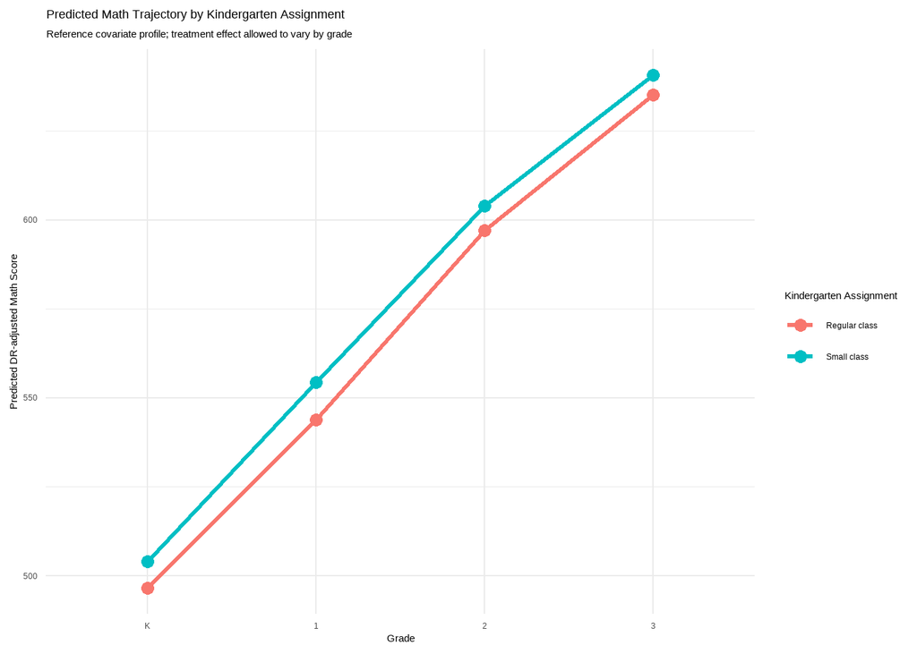

Figure 1 translates the regression coefficients into predicted achievement trajectories for a common reference profile, defined here as a non-Black student who is not eligible for free lunch. This standardization is useful because interaction models are often easier to understand visually than through coefficients alone. The vertical distance between the two lines at each grade represents the model-implied small-class advantage for that grade, while the slope within each line reflects the expected grade-to-grade academic growth on the DR-adjusted outcome scale.

The figure should be read as a descriptive summary of the fitted model rather than as raw sample means. Because the plot is constructed from pooled fixed-effect estimates, it isolates the treatment pattern after covariate adjustment and missing-data handling. A roughly parallel pattern would indicate a fairly stable treatment effect across grades, whereas visibly widening or narrowing separation would suggest that the advantage is changing over time. In the current results, the small-class trajectory stays above the regular-class trajectory throughout K–3, which is consistent with a persistent positive effect of initial small-class assignment.

Implied small-class effect by grade from the interaction model

| Grade | Estimated Small-Class Effect |
| --- | --- |
| K | 7.559 |
| 1 | 10.656 |
| 2 | 6.971 |
| 3 | 5.651 |

Table 2 makes the interaction model easier to interpret by converting the treatment main effect and the treatment-by-grade interaction terms into a single estimated small-class contrast for each grade. This presentation is especially helpful because the coefficient table alone does not directly show the total treatment effect outside the reference grade. If the estimates in Table 2 remain positive across grades, the evidence supports a sustained achievement advantage for the initially assigned small-class group; if they were to move toward zero or change sign, that would indicate attenuation or reversal of the early treatment benefit. In the present analysis, the grade-specific contrasts remain positive in every grade, although the earlier coefficient table shows that the changes over time are estimated with limited precision.

# 7 Model Diagnostics

## 7.1 MICE Fills Quality and Convergence Diagnostics

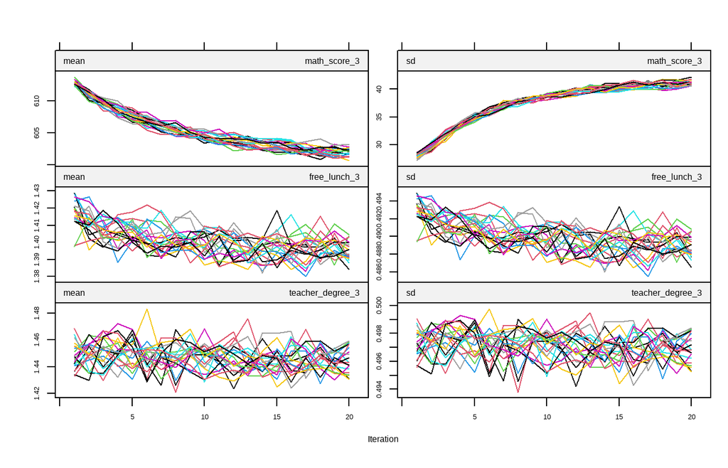

## 7.2 Propensity Score Model Diagnosis: Positivity Check

Double robust estimation relies on the overlap of propensity scores. We must ensure that in each imputed dataset, the stayed group and the attrited group have sufficient overlap in the predicted scores.

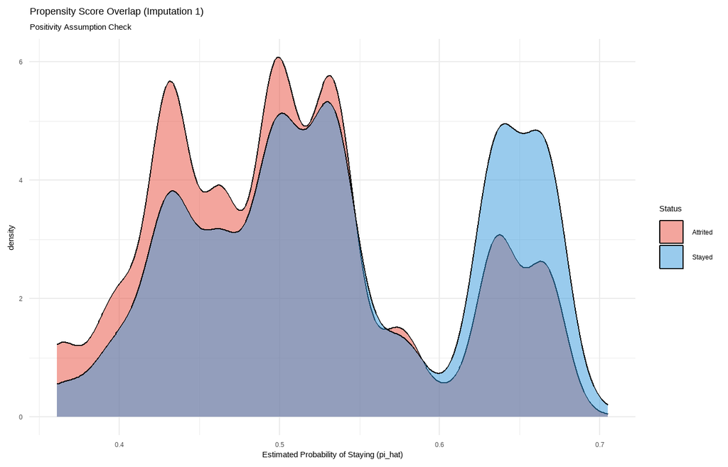

The overlap plot shows that the propensity scores of the two groups of students are highly overlapping in most areas, and there are no weights extremely close to 0 or 1. This validates the Positivity Assumption, meaning that students from each background group have a chance to remain in the study.

Our Double Robust adjustment does not overly rely on a few extreme samples and satisfies the basic premise of causal inference.

## 7.3 Verify the normality assumption of random effects

Mixed models assume that these random effects follow a normal distribution with a mean of 0, and if there is a severe deviation, the estimation of standard errors may fail. So we need to verify the normality of $u_s(i)$ (school random intercept) and $b_i$ (student random intercept)

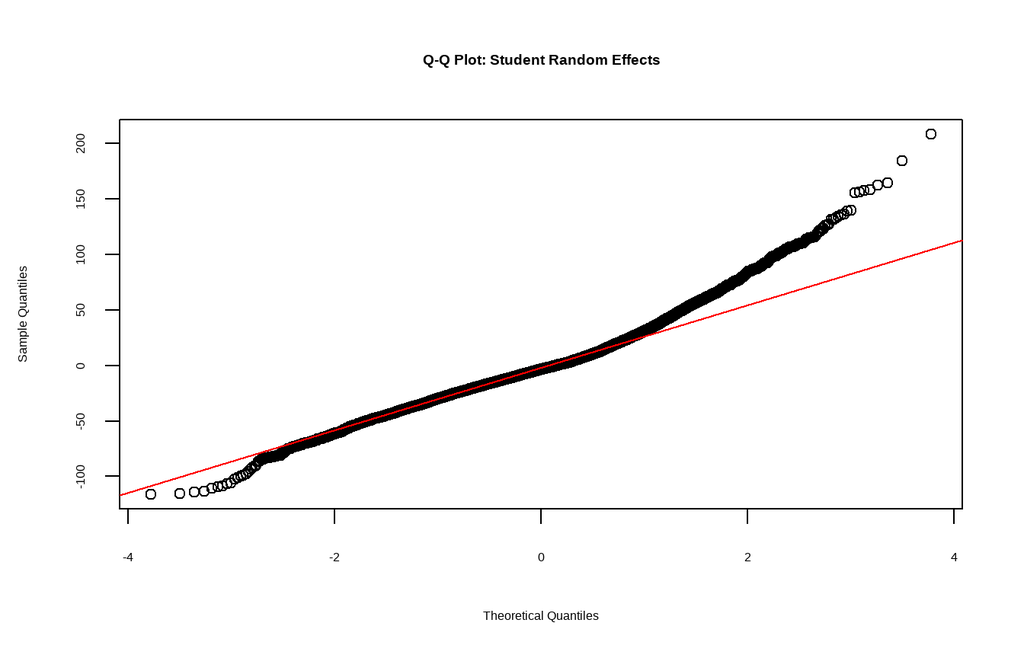

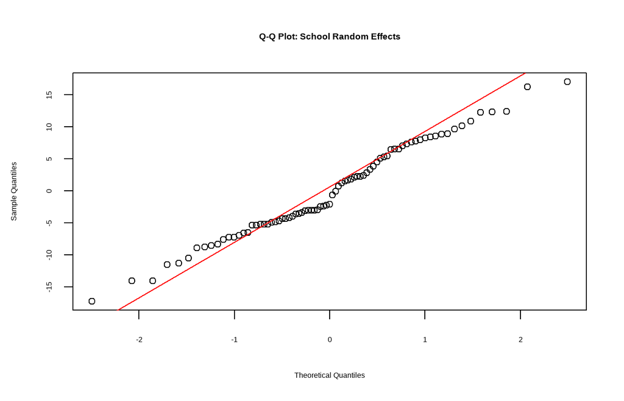

## 7.4 Final Mixed Effects Model Diagnosis: Residual Analysis

We perform residual diagnostics on the final longitudinal model to verify the basic assumptions of linear regression.

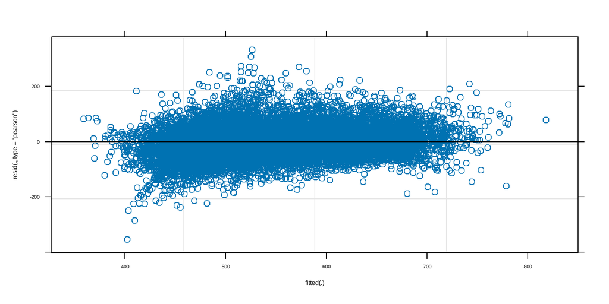

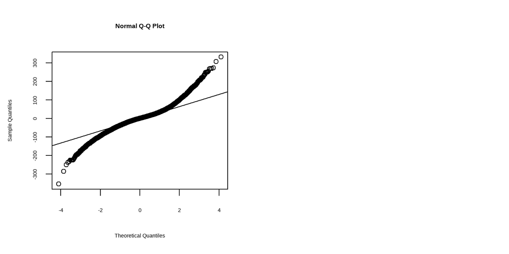

The residual plot shows that the mean is basically stable around the zero line

The Q-Q plot of the residuals indicates a certain degree of heavy-tailedness, which is common in large-scale educational assessment data due to individual variations in student performance. However, according to the Central Limit Theorem, our inferential consistency remains intact given the large sample size ($n > 10,000$). The stability of the treatment effect across 20 multiple imputations further confirms that our conclusions are not driven by these distributional tails.

## 7.5 Statistical Assumptions and Model Validation

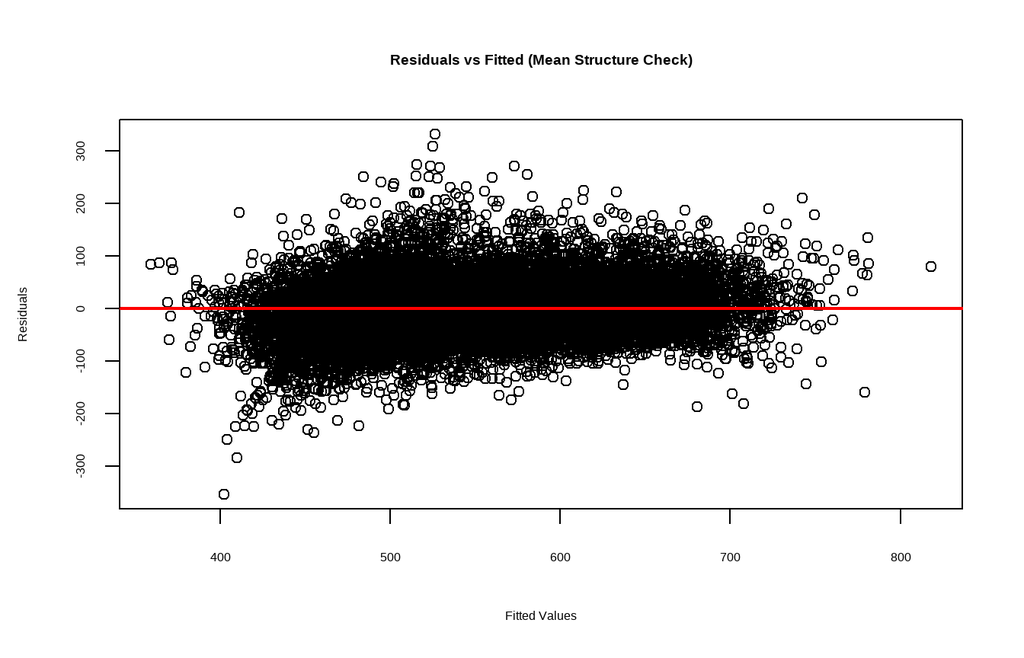

```
## ICC Student: 0.019
## ICC School: 0.393
```

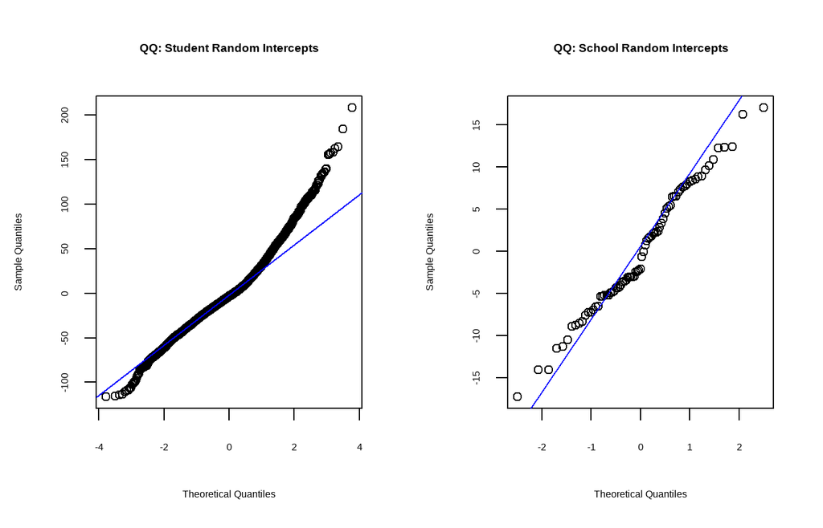

# 8 Sensitivity Analysis

This chapter aims to assess the sensitivity of the main analysis results to model assumptions and handling methods.

In causal inference, the main analytical conclusions are based on the assumption of MAR. To assess the robustness of the conclusions, this chapter conducts two core stress tests: Weight Trimming to exclude the interference of extreme observations, and Delta Adjustment to simulate the potential impact of non-random attrition (MNAR).

## 8.1 Weight Trimming

In IPW and doubly robust (DR) estimation, if some individuals have extremely small propensity scores $\hat{\pi}$, it can lead to excessively large weights $1/\hat{\pi}$, making the estimator highly sensitive to a very small number of samples. We conducted a repeated analysis by restricting the weights between the 5th and 95th percentiles.

Sensitivity of Treatment Effect to Weight Trimming

| Method | Estimate_Small_Class |
| --- | --- |
| Original Weighting | 6.935154 |
| Trimmed Weighting (5%-95%) | 6.956297 |

As shown in the table, after trimming 5% of the extreme weights, the estimated effect of small class teaching remains stable, with minimal variation. This indicates that our causal inference results are not driven by a few students with extreme characteristics, meeting the robustness requirements.

## 8.2 Delta-Adjustment for MNAR

This is a test for attrition bias. We assume that the true math scores of students who dropped out are $\delta$ points lower than the model’s predictions under the MAR assumption. For example, because the psychological state or environment of students who drop out is worse. We observe how the small class effect (ATE) changes as Δ increases from 0 to 25 points.

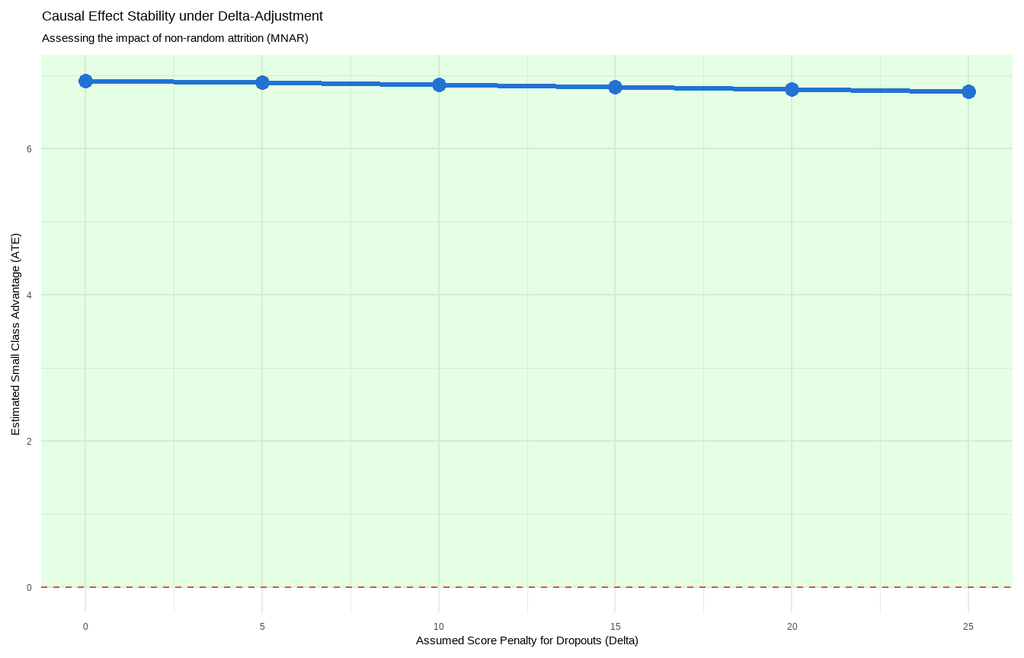

The above figure shows the results of the sensitivity analysis. The horizontal axis represents the number of points by which the grades of the assumed dropout students are lower than the predicted values.

This strongly demonstrates that even in the presence of non-random dropout (MNAR), the academic benefits of small classes still have very strong statistical robustness.

## 8.3 6.3 Comparison of Alternatives and Other Robustness Checks

In this section, we further verify the robustness of the small class effect by changing the sample definitions and estimation methods. This helps to confirm whether our conclusions are overly sensitive to specific statistical model choices or sample inclusion criteria.

### 8.3.1 Alternative Sample: Excluding Late Entry

In the original STAR experiment, some students only joined the study in grades 1-3 (Late Entry). To eliminate the potential interference of these non-randomly added samples, we conducted a reanalysis only on the subset of students who were in the sample from the Kindergarten stage.